# R中的微分方程

liutong

2022-02-15

# 1 R中的微分方程

## 1.1 相关R包

- deSolve：最主要的积分包
- rootSolve：求稳态解
- bvpSolve：求解边值问题
- ReacTran：偏微分方程
- simecol：构建模型的动态环境

## 1.2 简单环境相关模型

### 1.2.1 拟一级动力学降解动力学

拟一级降解动力学可以表示为$\frac{dC}{dt} = -kC$。

```r
f1 = function(t, y, parms){
    with(as.list(parms),{
        dy = -1 * parms[1] * y
        return(list(dy))
    })
}

times = seq(0, 5, length.out = 50)
f1_out = ode(
    times = times, # 求解时间
    y = 10, # 初始浓度
    func = f1, # 模型函数
    parms = c(1) # 模型参数
)
```

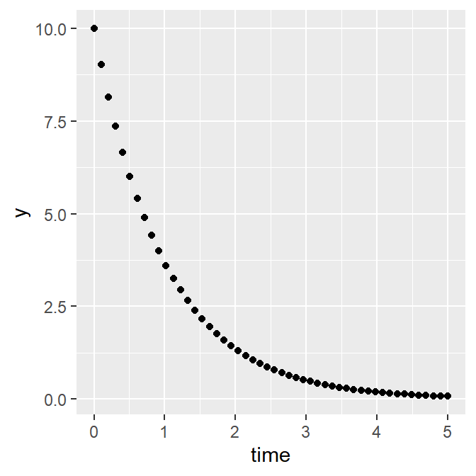

```r
f1_out %>%
    as.data.frame() %>%
    setNames(c("time", "y")) %>%
    ggplot(aes(time, y)) +
    geom_point()
```

### 1.2.2 拟二级动力学降解动力学

拟二级降解动力学可以表示为$\frac{dC}{dt} = -kC^2$。

```r
f2 = function(t, y, parms){
    with(as.list(parms),{
        dy = -1 * parms[1] * y^2
        return(list(dy))
    })
}

times = seq(0, 5, length.out = 50)
f2_out = ode(
    times = times, # 求解时间
    y = 10, # 初始浓度
    func = f2, # 模型函数
    parms = c(1) # 模型参数
)
```

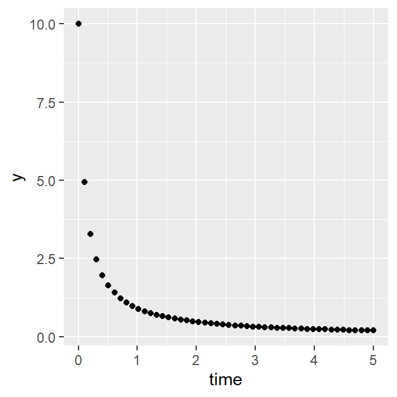

```r
f2_out %>%
    as.data.frame() %>%
    setNames(c("time", "y")) %>%
    ggplot(aes(time, y)) +
    geom_point()
```

### 1.2.3 反硝化

```r
f_n = function(t, y, parms) {
    with(as.list(c(y, parms)), {
        dNO3 = -1 * k1 * NO3
        dNO2 = k1 * NO3 - k2 * NO2
        return(
            list(c(dNO3, dNO2))
        )
    })
}
times = seq(0, 5, length.out = 50)
parms_N = c(k1 = 1, k2 = 0.5)
y_ini = c(NO3 = 10, NO2 = 0)

f_n_out = ode(
    times = times,
    y = y_ini,
    parms = parms_N,
    func = f_n
)
```

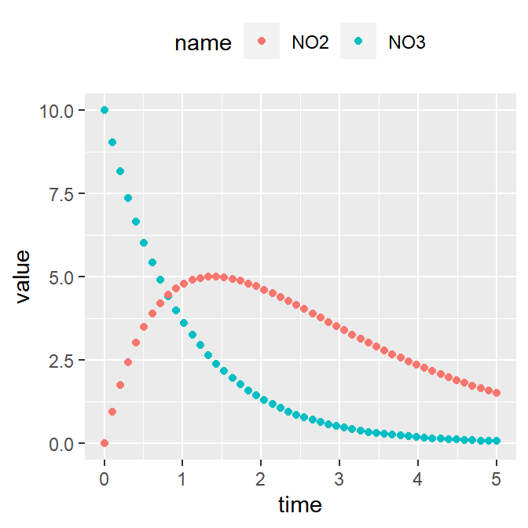

```r
f_n_out %>%
    as.data.frame() %>%
    pivot_longer(cols = -1) %>%
    ggplot(aes(time, value, color = name)) +
    geom_point() +
    theme(legend.position = 'top')
```

## 1.3 其他模型

### 1.3.1 Logistic增长模型

微分方程：
$$\frac{dN}{dt} = r·N·(1 - \frac{N}{K})$$

数值求解该方程：

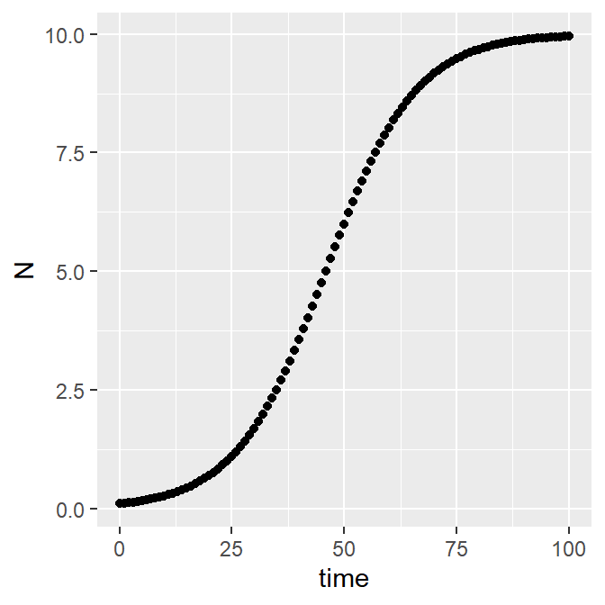

```r
library(deSolve)
# 模型定义
model <- function(time, y, parms) {
    with(as.list(c(y, parms)), {
        dN <- r * N * (1 - N / K)
        return(list(dN))
    })
}
# 参数定义
y <- c(N = 0.1)
parms <- c(r = 0.1, K = 10)
times <- seq(0, 100, 1)
# 数值求解
out <- ode(y, times, model, parms)
out %>% as.data.frame()  %>%
    ggplot(aes(time, N)) +
    geom_point()
```

模型求解的诊断：

```r
diagnostics(out)
```

```
##
## --------------------
## lsoda return code
## --------------------
##
##   return code (idid) =  2
##   Integration was successful.
##
## --------------------
## INTEGER values
## --------------------
##
##   1 The return code : 2
##   2 The number of steps taken for the problem so far: 105
##   3 The number of function evaluations for the problem so far: 211
##   5 The method order last used (successfully): 5
##   6 The order of the method to be attempted on the next step: 5
##   7 If return flag =-4,-5: the largest component in error vector 0
##   8 The length of the real work array actually required: 36
##   9 The length of the integer work array actually required: 21
##  14 The number of Jacobian evaluations and LU decompositions so far: 0
##  15 The method indicator for the last succesful step,
##            1=adams (nonstiff), 2= bdf (stiff): 1
##  16 The current method indicator to be attempted on the next step,
##            1=adams (nonstiff), 2= bdf (stiff): 1
##
## --------------------
## RSTATE values
## --------------------
##
##   1 The step size in t last used (successfully): 1
##   2 The step size to be attempted on the next step: 1
##   3 The current value of the independent variable which the solver has reached: 100.8645
##   4 Tolerance scale factor > 1.0 computed when requesting too much accuracy: 0
##   5 The value of t at the time of the last method switch, if any: 0
##
```

### 1.3.2 常微分方程组：刚性常微分方程

#### 1.3.2.1 问题定义

- 无外力的刚体欧拉方程
- 三个因变量（$y_1, y_2, y_3$），旋转矢量的坐标
- （$I_1, I_2, I_3$）是主惯性矩

#### 1.3.2.2 问题的数学形式

**微分方程**

$$y_1^{'} = (I_2 - I_3)/I_1 ·y_2y_3 \\
y_2^{'} = (I_3 - I_1)/I_2 ·y_1y_3 \\
y_3^{'} = (I_1 - I_2)/I_3 ·y_1y_2$$

**参数**

$$I_1 = 0.5, I_2 = 2, I_3 = 3$$

**初值**

$$y_1(0) = 1, y_2(0) = 0, y_3(0) = 0.9$$

#### 1.3.2.3 模型求解

```r
rigidode <- function(t, y, parms) {
    dy1 <- -2 * y[2] * y[3]
    dy2 <- 1.25 * y[1] * y[3]
    dy3 <- -0.5 * y[1] * y[2]
    list(c(dy1, dy2, dy3))
}
yini <- c(y1 = 1, y2 = 0, y3 = 0.9)
times <- seq(from = 0, to = 20, by = 0.01)
out <- ode(times = times, y = yini, func = rigidode, parms = NULL)
```

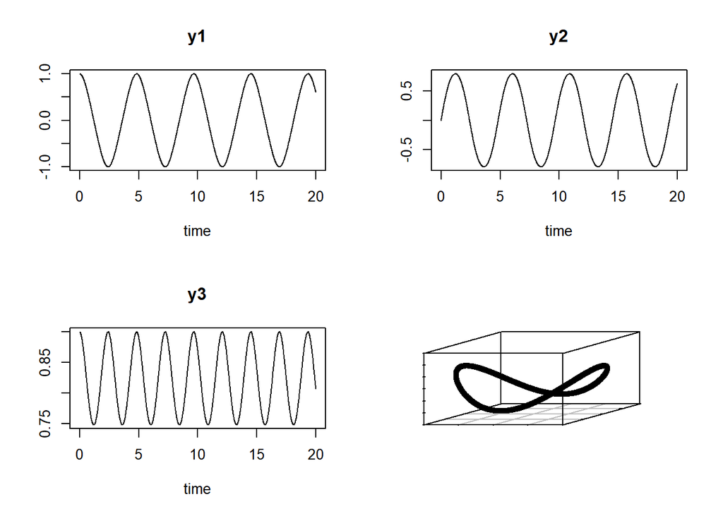

```r
plot(out)
library(scatterplot3d)
par(mar = c(0, 0, 0, 0))
scatterplot3d(out[,-1], xlab = "", ylab = "", zlab = "", label.tick.marks = FALSE)
```

### 1.3.3 混沌系统 - 洛伦兹方程

```r
chaos <- function(t, state, parameters) {
    with(as.list(c(state)), {
        dx <- -8 / 3 * x + y * z
        dy <- -10 * (y - z)
        dz <- -x * y + 28 * y - z
        list(c(dx, dy, dz))
    })
}
yini <- c(x = 1, y = 1, z = 1)
yini2 <- yini + c(1e-6, 0, 0)
times <- seq(0, 100, 0.01)
out <- ode(y = yini, times = times, func = chaos, parms = 0)
out2 <- ode(y = yini2, times = times, func = chaos, parms = 0)
```

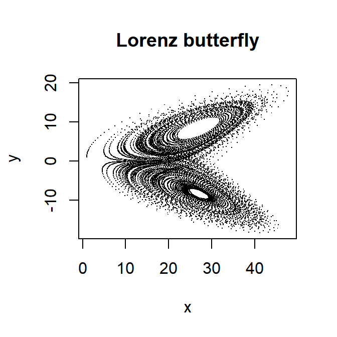

```r
plot(out[, "x"], out[, "y"],
    pch = ".", main = "Lorenz butterfly",
    xlab = "x", ylab = "y"
)
```

### 1.3.4 扩散、对流和反应：使用`ReacTran`求解偏微分方程

#### 1.3.4.1 偏微分方程

**以对流扩散方程形式处理偏微分方程**

许多二阶偏微分方程能写成对流扩散方程形式：

$$\frac{\partial C}{\partial t} = - v \frac{\partial C}{\partial x} + D \frac{\partial^2 C}{\partial x^2} + f(t,x,C)$$

对于二维和三维形式也能这样处理。

**栗子：一维波函数**

$$\frac{\partial^2 U}{\partial t^2} = c^2 \frac{\partial^2 U}{\partial x^2}$$

以上方程可以写作：

$$\frac{du}{dt} = v \\ \frac{\partial v}{\partial t} = c^2 \frac{\partial^2 U}{\partial x^2}$$

**R中处理PDE的包**

R中有三个包能处理PDE：

- ReacTran：用于PDE数值近似的方法
- deSolve：瞬态求解
- rootSolve：稳态求解

#### 1.3.4.2 1D偏微分方程

**数值求解波函数**

```r
library(ReacTran)

wave <- function(t, y, parms) {
    u <- y[1:N]
    v <- y[(N + 1):(2 * N)]
    du <- v
    dv <- tran.1D(
        C = u, C.up = 0, C.down = 0, D = 1,
        dx = xgrid
    )$dC
    list(c(du, dv))
}

xgrid <- setup.grid.1D(-100, 100, dx.1 = 0.2)
x <- xgrid$x.mid
N <- xgrid$N
uini <- exp(-0.2 * x^2)
vini <- rep(0, N)
yini <- c(uini, vini)
times <- seq(from = 0, to = 50, by = 1)

out <- ode.1D(yini, times, wave, parms,
    method = "adams",
    names = c("u", "v"), dimens = N
)
```

**Plotting 1-D PDEs: matplot.1D**

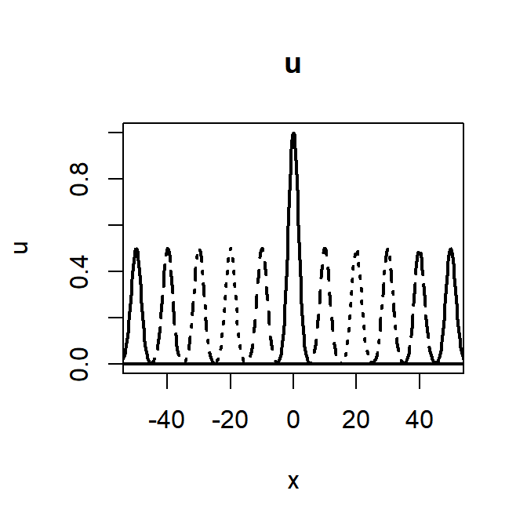

```r
outtime <- seq(from = 0, to = 50, by = 10)
 matplot.1D(out, which = "u", subset = time %in% outtime, grid = x, xlab = "x", ylab = "u", type = "l", lwd = 2, xlim = c(-50, 50), col="black")
```

**Plotting 1-D PDEs: image**

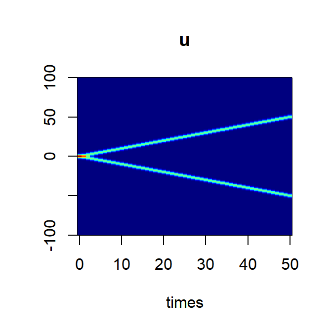

```r
image(out, which = "u", grid = x)
```

## 1.4 加速方程求解

### 1.4.1 加速方法

1. 使用矩阵
2. 一部分代码使用Fortran或C
3. 全部代码使用Fortran或C

*使用矩阵能够显著加速模型求解，同时保持R代码的灵活性。*

*使用编译语言（Fortran或C）能够进一步减少CPU时间，但是会带来代码开发的复杂度。*